# PyLayers

## A Site-Specific Mobile Indoor Radio Channel Modeling Platform

## From Graph-Based Ray Tracing to Indoor Positioning

## Overview

### 2014

# What is PyLayers ?

- PyLayers is **Open Source**
- PyLayers is an evolutive platform for **education and research** in radio propagation
- PyLayers is a radio propagation simulator fully written in **Python** langage
- PyLayers is organized as a set of specialized independent modules
  - Good for maintainability and further evolution
- PyLayers adresses the prediction of radio observable for **localization in Indoor environments**
- PyLayers adresses various radio standard including **UWB** radio
- PyLayers adresses realistic **human mobility and motion**
- PyLayers aims to connect with **upper Layer abstraction**

# List of the main modules

# Layout of Indoor Environments

- The very first thing to do, is to describe the selected propagation environement.
- The manner this environement is described has very strong implications on rays algoritms performances.
- The design choice which has been made, is to heavily relying on the **graph data structure**

To go further, we need to import the following specialized module

```python
from pylayers.gis.layout import *
```

# Loading a Floor Plan (Layout)

- The chosen environement corresponds to the office building where an UWB Impulse Radio measurement campaign took place during the WHERE1 FP7 project.
- Several format are supported (including `.osm`)

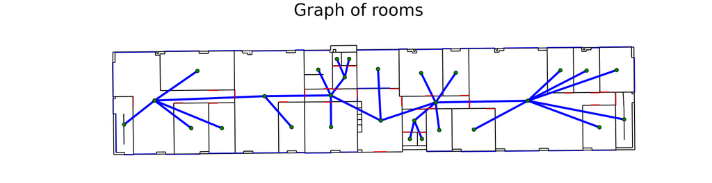

```python
L=Layout('WHERE1.ini')
f = figure(figsize(30,30))
plt.axis('off')
f,a = L.showG('r',nodes=True,node_size=80,node_color='g',edge_color='b',width=5,fig=f)
t = plt.title('Graph of rooms',fontsize=40)
```

# Graph of Ways

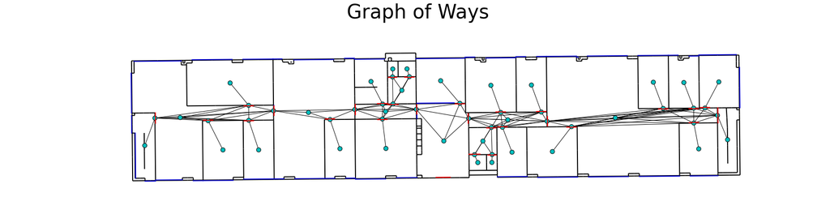

```python
f = figure(figsize(30,30))
plt.axis('off')
f,a = L.showG('w',nodes=True,node_size=80,node_color='c',edge_color='k',width=1,fig=f)
t =plt.title('Graph of Ways',fontsize=40)
```

# Link Simulation

For enabling electromagnetic simulation we load the following modules

- `radionode`
  - coordinates
  - 3D orientation
  - antenna object
- `link`
  - 2 `RadioNode`
  - 1 `Layout`

```python
from pylayers.simul.radionode import *
from pylayers.simul.link import *
```

Loading the Tx and Rx points from the WHERE1-M1 measurement campaign.

```python
rx = RadioNode(_fileini='w2m1rx.ini',_fileant='defant.vsh3')
tx = RadioNode(_fileini='w2m1tx.ini',_fileant='defant.vsh3')
```

# Link Simulation

- Links are saved in `hdf5` format
- All Links data members are evaluated once and stored

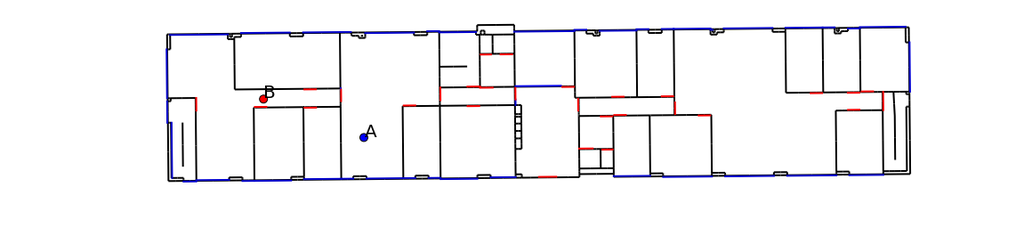

```python
Lk = DLink(L=L,a=tx.points[1],b=rx.points[54],cutoff=5,verbose=False)
Lk.eval()
f,a = Lk.show()
```

# Main Link members

## The Signature `.Si`

```python
Lk.Si.keys()
print Lk.Si[12].shape
print Lk.Si[12][0,:]
print Lk.Si[12][1,:]
```

```
(96, 12)
[ 70 136  46 135 140   5 140 135  46 136  48  35]
[1 2 2 2 2 1 2 2 2 2 2 2]
```

- Signatures are rays potentialities
- A set of Signature is calculated from one Layout cycle to an other Layout cycle
- A Signature consists of 2 lists
  - A list of interaction entities (point (<0) or segment (>0))
  - A list of type of interactions (1:R, 2:T, 3:D)
- The **same signature** is used for calculation of rays from one cycle to an other cycle

# Main Link Members

## The Rays .R

```python
Lk.R
```

```
Rays3D
----------
3 / 2 : [0 1]
4 / 8 : [2 3 4 5 6 7 8 9]
5 / 22 : [10 11 12 13 14 15 16 17 18 19 20 21 22 23 24 25 26 27 28 29 30 31]
6 / 48 : [32 33 34 35 36 37 38 39 40 41 42 43 44 45 46 47 48 49 50 51 52 53 54 55 56
 57 58 59 60 61 62 63 64 65 66 67 68 69 70 71 72 73 74 75 76 77 78 79]
7 / 62 : [ 80  81  82  83  84  85  86  87  88  89  90  91  92  93  94  95  96  97
  98  99 100 101 102 103 104 105 106 107 108 109 110 111 112 113 114 115
 116 117 118 119 120 121 122 123 124 125 126 127 128 129 130 131 132 133
 134 135 136 137 138 139 140 141]
8 / 44 : [142 143 144 145 146 147 148 149 150 151 152 153 154 155 156 157 158 159
 160 161 162 163 164 165 166 167 168 169 170 171 172 173 174 175 176 177
 178 179 180 181 182 183 184 185]
9 / 4 : [186 187 188 189]
-----
ni : 1258
nl : 2706
```

### Group of rays with 3 interactions

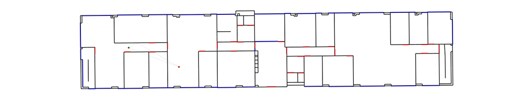

```python
Lk.R.show(Lk.L,figsize=(30,30),i=3,alpha=1)
```

### Group of rays with 4 interactions

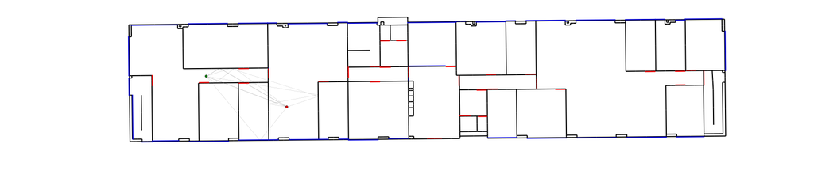

```python
Lk.R.show(Lk.L,figsize=(30,30),i=4)
```

### All group of rays (from 3 to 9 interactions)

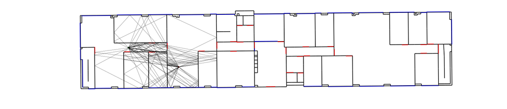

```python
Lk.R.show(Lk.L,figsize=(30,30))
```

# Main Link members

## The Propagation Channel `.C`

- $\mathbf{\tilde{C}(f)} = \left[\matrix { C_{\theta,\theta} & C_{\theta,\phi}\\C_{\phi,\theta} & C_{\phi,\phi}}\right]$

```python
Lk.C
```

```
Ctilde
---------
(190, 181)
Nray : 190
fmin(GHz) : 2.0
fmax(GHz): 11.0
Nfreq : 181
Methods
---------
 prop2tran(a=theta,b=phi,Friis=False)
 energy()
 doadod(cmap=plt.cm.hot_r,s=30,fontsize=12,phi=(0,360))
 mobility(v,dt)
 show(mode=linear)
 sort()
```

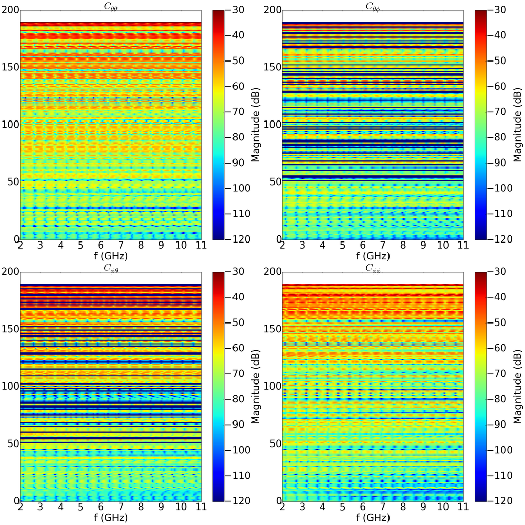

```python
Lk.C.sort('energy')
f,a= Lk.C.show(cmap='jet',fontsize=40,typ='l20',vmin=-120,vmax=-30)
```

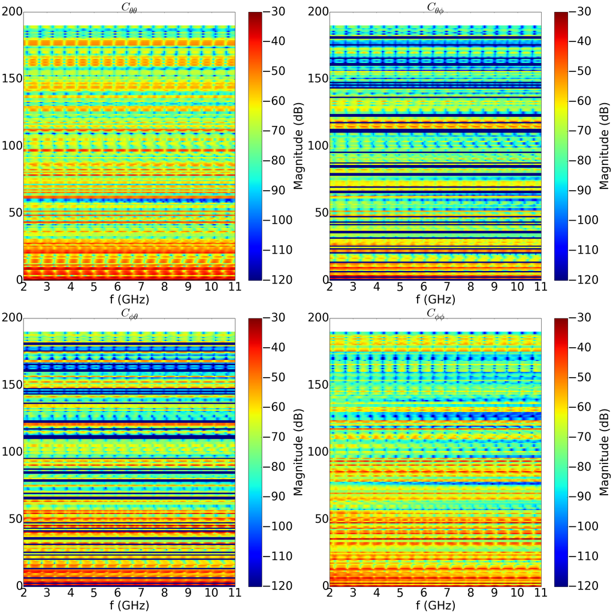

```python
Lk.C.sort('tauk')
f,a=Lk.C.show(cmap='jet',fontsize=40,typ='l20',vmax=-30,vmin=-120)
```

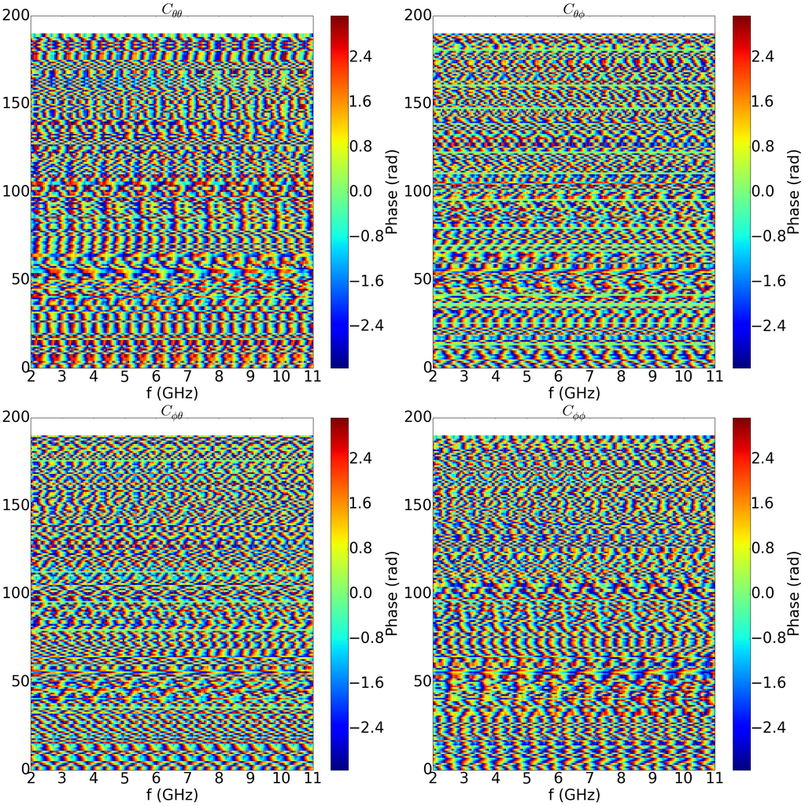

```python
Lk.C.sort('tauk')
f,a=Lk.C.show(cmap='jet',fontsize=40,typ='r')
```

# Main Link members

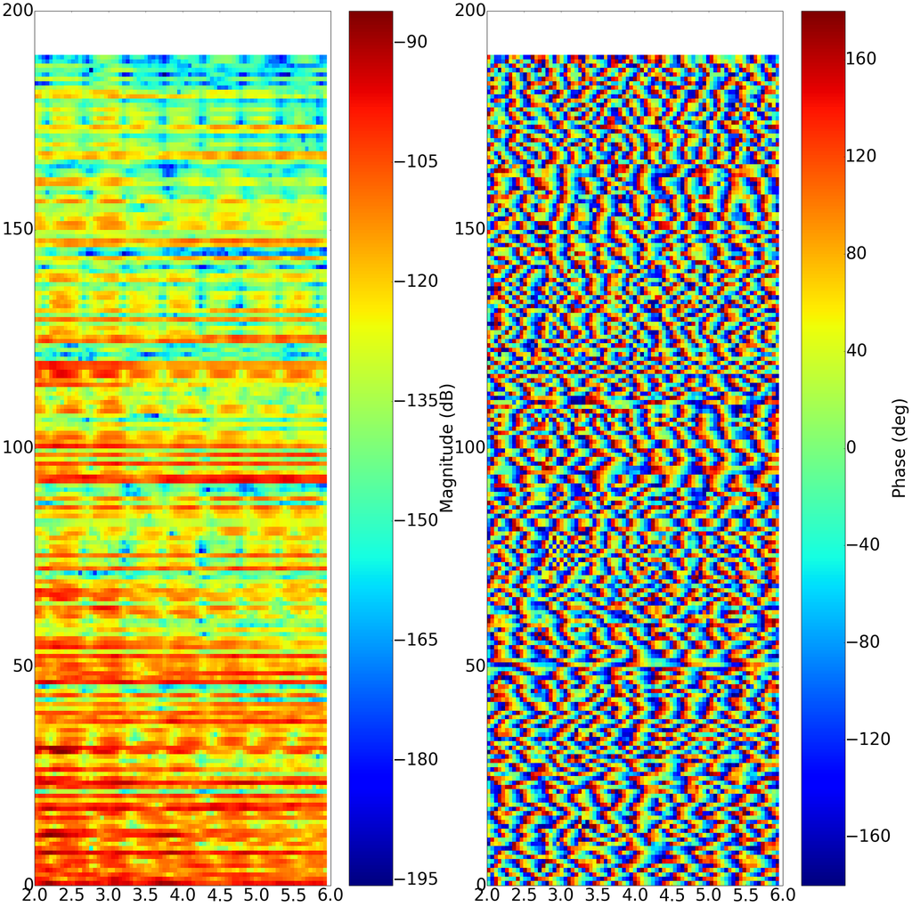

```python
f,la=Lk.H.show(cmap='jet',fontsize=40)
```

# Internal Description of Complex Signals

# Materials and Slabs

# Antennas and Propagation

# Simulation of a Radio Link

# Handling human mobility

# Comparison with measurements

# Thanks!

```python
from IPython.display import display, HTML
s = """

<style>

.rendered_html {
    font-family: "proxima-nova", helvetica;
    font-size: 150%;
    line-height: 1.3;
}

.rendered_html h1 {
    margin: 0.25em 0em 0.5em;
    color: #015C9C;
    text-align: center;
    line-height: 1.2;
    page-break-before: always;
}

.rendered_html h2 {
    margin: 1.1em 0em 0.5em;
    color: #26465D;
    line-height: 1.2;
}

.rendered_html h3 {
    margin: 1.1em 0em 0.5em;
    color: #002845;
    line-height: 1.2;
}

.rendered_html li {
    line-height: 1.5;
}

.prompt {
    font-size: 120%;
}

.CodeMirror-lines {
    font-size: 120%;
}

.output_area {
    font-size: 120%;
}

notebook {
    background-image: url('files/images/background.png');
}

h1.bigtitle {
    margin: 4cm 1cm 4cm 1cm;
    font-size: 300%;
}

h3.point {
    font-size: 200%;
    text-align: center;
    margin: 2em 0em 2em 0em;
    #26465D
}

.logo {
    margin: 20px 0 20px 0;
}

a.anchor-link {
    display: none;
}

h1.title {
    font-size: 250%;
}

</style>
"""
display(HTML(s))
```